# Instagram user behaviour

## What is the length of time I typically spend for each session?

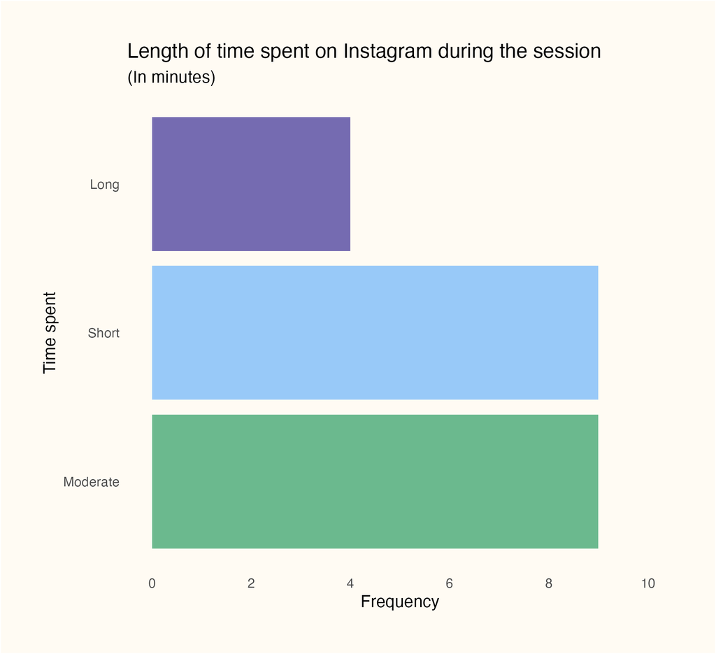

For this plot, I have decided to gauge how long I typically spend for each session on Instagram, classifying the minutes spent to different categories (i.e., 1-5 minutes = Short, 10-20 minutes = Moderate, 30-60 minutes = Long). I have chosen a bar plot to best represent the observation for this data, and found out that I mostly spent 1-20 minutes for the each session that I open the app as the majority of the sessions falls within the ‘Short’ and ‘Moderate’ category, and less data for the ‘Long’ category Personally, this might be a result of Instagram contents that gets repetitive the more we scroll through and spend time on it, which bores me out. Whereas, the data in the ‘Long’ category is mostly a result of using Instagram for communication purposes (Direct Message).

## What is the purpose main purpose of opening the Instagram app?

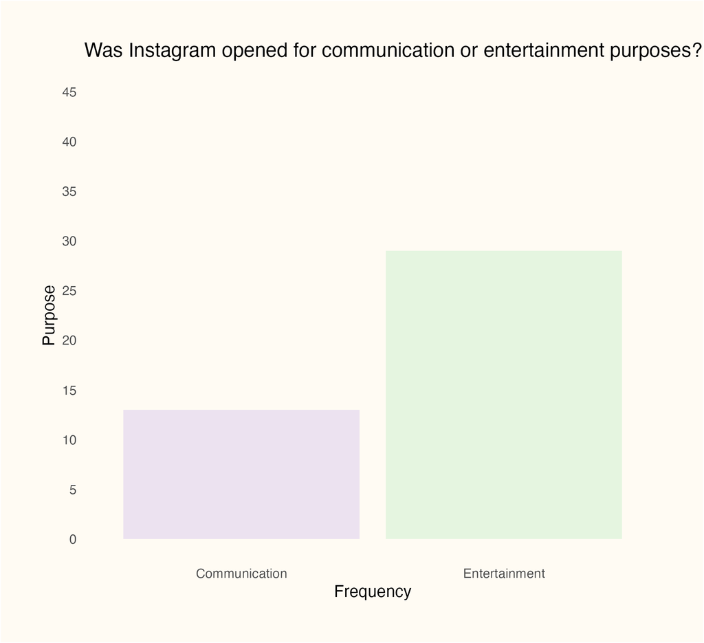

Main purpose

For the second plot, I have created a bar plot, representing the purpose that each session on Instagram was opened for. The plot shows that I have opened Instagram for entertainment purposes twice as much as for communication purposes. However, this might not have been an accurate representative of the data as the ‘Communication’ category only accounts for the amount of times I have opened Instagram to send messages through Direct Message (DM) or network with my mutuals, whereas the ‘Entertainment’ category accounts for more purposes such as scrolling on reels, scrolling on homepage, watch my mutual’s Instagram stories, and making a post.

## How does the explore page relate to the purpose of Instagram use?

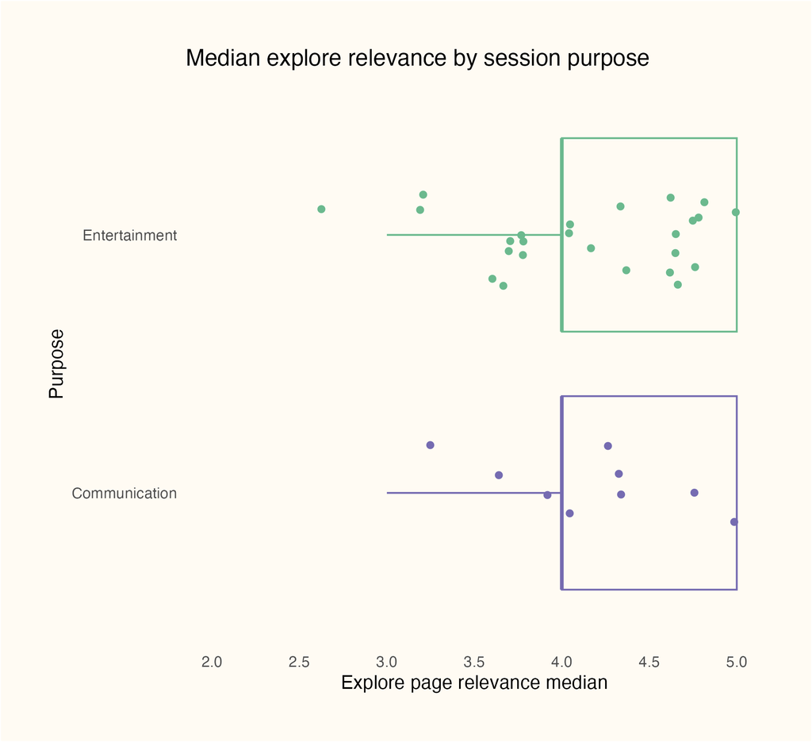

Explore page relevance

## Questionnaires amount completed within a day

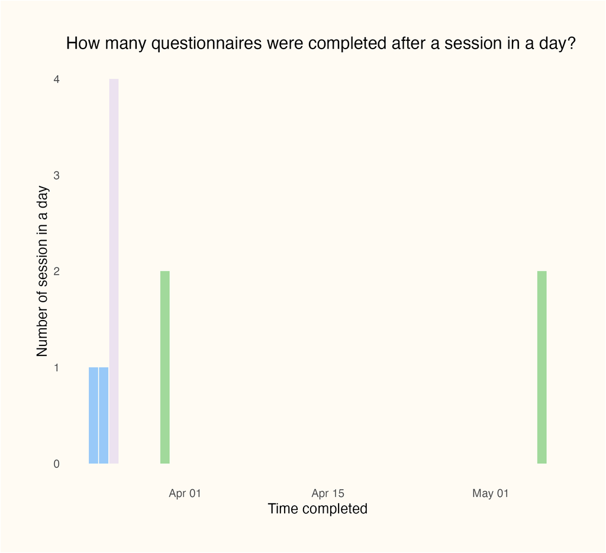

Timestamp

For the fourth plot, I created a bar chart showing how many questionnaires were completed after Instagram sessions on each day. As seen in the plot, there are noticeable gaps in the timeline. These gaps exist as I’m using the same questionnaire data from Project 2, and have added more entries specifically for Project 4 to meet the updated requirements. This means the data isn’t continuous across the whole time range, which is why you see clusters of activity at the beginning and end, but nothing in the middle. Regardless, this plot gives a general idea of how often I engaged with the questionnaires after each session that Instagram was opened.